# Business Statistics Assessment IB94X0 2024-2025 #2

# 4 Question 2 - Effect of various factors on Customer Satisfaction

This report fulfills the requests to analyse the factors which affect the customers satisfaction across different stores. The factors in the dataset include - customer satisfaction scores, staff job satisfaction scores, average delivery times of large and custom items, whether the store is carrying a new range of products, and the socio-economic categorization of the stores (low, medium, and high SES). The following steps are covered to come to a conclusion.

1. Data Loading
2. Initial Data Checks and Data Understanding
3. Data Exploration
4. Correlation Analysis
5. Simple Linear Models
6. Multiple Linear Regression
7. Comparison of Models
8. Conclusion

## 4.1 Data Loading

```r
raw_cs.data <- read_csv("cust_satisfaction.csv")
#Loaded the dataset containing the Customer Satisfaction Data.
```

## 4.2 Initial Data checks and data understanding

```r
#This data captures the following factors whicha are collected across stores to see how their customer satisfaction values fare against them:


data_dictionary_cs <- data.frame(
  Variable = c("SES_category", "customer.satisfaction", "staff.satisfaction", "delivery.time", "new_range"),
  Description = c(
    "Socio-economic status category of each store (low, medium, or high)",
    "Average customer satisfaction score for each store",
    "Average staff job satisfaction score for each store",
    "Average delivery time of large and custom items for each store",
    "Indicates whether the store is carrying a new range of products"
  )
)

data_dictionary_cs %>%
  kable("html", col.names = c("Variable", "Description"), align = "l") %>%
  kable_styling(
    bootstrap_options = c("striped", "hover",  "responsive"),
    full_width = FALSE,
    position = "left") %>%
  column_spec(1, bold = TRUE, border_right = TRUE, border_left = TRUE) %>%
  column_spec(2, border_left = TRUE,border_right = TRUE) %>%
  row_spec(0, bold = TRUE, background = "#D3D3D3") %>%
  kable_classic(full_width = FALSE, html_font = "Arial")
```

| Variable | Description |
| --- | --- |
| SES_category | Socio-economic status category of each store (low, medium, or high) |
| customer.satisfaction | Average customer satisfaction score for each store |
| staff.satisfaction | Average staff job satisfaction score for each store |
| delivery.time | Average delivery time of large and custom items for each store |
| new_range | Indicates whether the store is carrying a new range of products |

```r
summary(raw_cs.data)
```

```
##  SES_category       customer.satisfaction staff.satisfaction delivery.time   new_range
##  Length:300         Min.   :3.760         Min.   :4.850      Min.   :32.96   Mode :logical
##  Class :character   1st Qu.:6.099         1st Qu.:6.216      1st Qu.:52.46   FALSE:142
##  Mode  :character   Median :7.006         Median :6.634      Median :60.45   TRUE :158
##                     Mean   :6.930         Mean   :6.751      Mean   :59.60
##                     3rd Qu.:7.865         3rd Qu.:7.274      3rd Qu.:66.79
##                     Max.   :9.670         Max.   :8.860      Max.   :92.48
```

```r
#The summary shows us that we have one character column of SES_category. We also have one binary categorical column of new_range. Rest are numerical values. There are no NA values in the dataset.
```

```r
unique(raw_cs.data$SES_category)
```

```
## [1] "Medium" "High"   "Low"
```

```r
unique(raw_cs.data$new_range)
```

```
## [1] FALSE  TRUE
```

```r
raw_cs.data$SES_category <- as.factor(raw_cs.data$SES_category)
raw_cs.data$new_range <- as.factor(raw_cs.data$new_range)

#We check the unique values in both - SES_category and new_range. Since they are categorical and if we want to include them in our model, we need to mention that they are factors and not numerical values. Hence instead of converting them manually, with use of the factor function we convert them to factors.
```

```r
#We can observe that the columns with numeric values don’t have consistent formats. (decimals) In order to be sure, we also confirm the datatypes for each column and make the numeric formats consistent overall.


head(raw_cs.data)
```

```
## # A tibble: 6 × 5
##   SES_category customer.satisfaction staff.satisfaction delivery.time new_range
##   <fct>                        <dbl>              <dbl>         <dbl> <fct>
## 1 Medium                        7.27               6.88          66.7 FALSE
## 2 Medium                        7.93               7.44          68.2 FALSE
## 3 Medium                        7.12               7.15          70.7 FALSE
## 4 High                          6.35               6.47          61.4 TRUE
## 5 High                          6.78               7.06          57.7 TRUE
## 6 Medium                        8.07               7.03          38.0 TRUE
```

```r
#just to make sure, round decimal to one.

raw_cs.data <- raw_cs.data %>%
  mutate(
    customer.satisfaction = round(as.numeric(customer.satisfaction), 1),
    staff.satisfaction = round(as.numeric(staff.satisfaction), 1),
    delivery.time = round(as.numeric(delivery.time), 1)
  )


head(raw_cs.data)
```

```
## # A tibble: 6 × 5
##   SES_category customer.satisfaction staff.satisfaction delivery.time new_range
##   <fct>                        <dbl>              <dbl>         <dbl> <fct>
## 1 Medium                         7.3                6.9          66.7 FALSE
## 2 Medium                         7.9                7.4          68.2 FALSE
## 3 Medium                         7.1                7.2          70.7 FALSE
## 4 High                           6.3                6.5          61.4 TRUE
## 5 High                           6.8                7.1          57.7 TRUE
## 6 Medium                         8.1                7            38   TRUE
```

```r
#first checking duplicate values before removing null as it can be possible reason
cat("Unique values in SES_category:", length(unique(raw_cs.data$SES_category, raw_cs.data$SES_category)), "\n")
```

```
## Unique values in SES_category: 300
```

```r
cat("Unique values in new_range:", length(unique(raw_cs.data$new_range, raw_cs.data$new_range)), "\n")
```

```
## Unique values in new_range: 300
```

```r
#so no duplicate values

#Now, the formats are consistent and we have also confirmed the datatypes for the columns.
```

## 4.3 Data Exploration

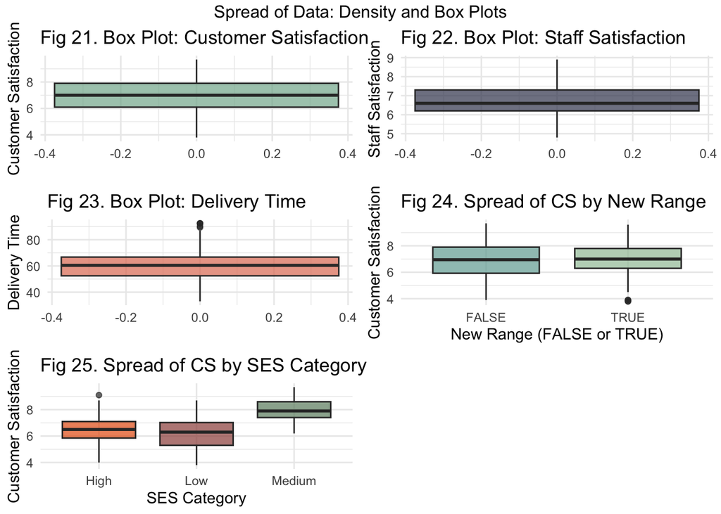

```r
#Since the SES_category and new_range are character values, we confirm if there are no different values as opposed to the general list of values for those columns.



box_plot_CustomerSatisfaction <- ggplot(raw_cs.data, aes(y = customer.satisfaction)) +
  geom_boxplot(fill = "#81B29A", alpha = 0.7) +
  labs(title = "Fig 21. Box Plot: Customer Satisfaction", y = "Customer Satisfaction", x = "") +
  theme_minimal()

box_plot_StaffSatisfaction <- ggplot(raw_cs.data, aes(y = staff.satisfaction)) +
  geom_boxplot(fill = "#3D405B", alpha = 0.7) +
  labs(title = "Fig 22. Box Plot: Staff Satisfaction", y = "Staff Satisfaction", x = "") +
  theme_minimal()

box_plot_DeliveryTime <- ggplot(raw_cs.data, aes(y = delivery.time)) +
  geom_boxplot(fill = "#E07A5F", alpha = 0.7) +
  labs(title = "Fig 23. Box Plot: Delivery Time", y = "Delivery Time", x = "") +
  theme_minimal()

boxplot_NewRange <- ggplot(raw_cs.data, aes(x = new_range, y = customer.satisfaction, fill = new_range)) +
  geom_boxplot(alpha = 0.7) +
  scale_fill_manual(values = c("#70a9a1", "#9ec1a3")) +
  theme_minimal() +
  labs(
    title = "Fig 24. Spread of CS by New Range",
    x = "New Range (FALSE or TRUE)",
    y = "Customer Satisfaction"
  ) +
  theme(legend.position = "none")

boxplot_SES_category <- ggplot(raw_cs.data, aes(x = SES_category, y = customer.satisfaction, fill = SES_category)) +
  geom_boxplot(alpha = 0.7) +
  scale_fill_manual(values = c("#e75e11", "#9b4d47", "#6a8a6c")) +
  theme_minimal() +
  labs(
    title = "Fig 25. Spread of CS by SES Category",
    x = "SES Category",
    y = "Customer Satisfaction"
  ) +
  theme(legend.position = "none")

grid.arrange(
  box_plot_CustomerSatisfaction,
  box_plot_StaffSatisfaction,
  box_plot_DeliveryTime,
  boxplot_NewRange,
  boxplot_SES_category,
  ncol = 2,
  nrow = 3,
  top = "Spread of Data: Density and Box Plots"
)
```

```r
#The data seems normally distributed without any major skewness. The box plots also show no major outliers and we can neglect them since the count is few and there can be a few high values considering it is a real life dataset.
```

## 4.4 Correlation Analysis

```r
correlation_raw_cs_data <- cor(raw_cs.data %>%
                                  select("customer.satisfaction", "staff.satisfaction", "delivery.time"),
                                use = "complete.obs",
                                method = "pearson")

print("Correlation Matrix (correlation_raw_cs_data):")
```

```
## [1] "Correlation Matrix (correlation_raw_cs_data):"
```

```r
print(correlation_raw_cs_data)
```

```
##                       customer.satisfaction staff.satisfaction delivery.time
## customer.satisfaction             1.0000000         0.45661133   -0.25904710
## staff.satisfaction                0.4566113         1.00000000   -0.06773562
## delivery.time                    -0.2590471        -0.06773562    1.00000000
```

The correlation matrix helps us understand the relativity between different factors that can affect the dependent variable. In the correlation matrix, we can observe the following:

1. Customer Satisfaction and Staff Satisfaction: The 0.45 value suggests a moderate positive correlation between Customer Satisfaction and Staff Satisfaction, suggesting that with increase in job satisfaction levels increases the satisfaction level of customer also increases. This can be confirmed since the staff which are happy and content with their jobs can provide better serivces to their customers.
2. Customer Satisfaction and Delivery Time: The -0.25 value suggests a weak negative correlation between Customer Satisfaction and Delivery Time, suggesting that with increase in delivery time the satisfaction level of customer decreases. This can be confirmed since the more time it takes for customers to get their product the discontent will increase.
3. Staff Satisfaction and Delivery Time: The -0.06 value indicates a very weak negative correlation between staff satisfaction and delivery time suggesting that there is a very weak or insignificant relationship between these them. This aligns with our real life understanding that the staff satisfaction levels are very vaguely related to delivery time of products for customers.

Although the correlation matrix shows us the relation between various factors, it doesn’t necessarily show the actual relationships when seen in real life context and they can be just casually related. Hence based on these observations, we will study them further in our models to find the most impacting factors.